# Modelo de Gerações Sobrepostas (OLG - *Overlapping Generations*)

Considere o problema de maximização, dados $(a_1, y_1, y_2)$: $$ W(a_1, \{y_t\}^2_{t=1}) \equiv \max_{-\bar{A}\ \le\ a_{t+1}\ \le\ y_t + a_t}\left\{ u(y_1 + a_1 - a_2) + \beta u(y_2 + a_2 - a_3) \right\} $$ em que:

- Preferência CRRA: $\ u(c) = \frac{c^{1-\delta}}{1 - \delta}$
- Riquezas: $a_t$
- Rendas: $y_t$
- Consumos:
  - $c_1 = y_1 + a_1 - a_2$
  - $c_2 = y_2 + (1 + r)a_2 - a_3$, com:
    - $r = 0 \implies R = (1+r) = 1$
    - $a_3 = 0$ (último período)
- Restrições, para todo $t$:
  - $a_{t+1} \ge - \bar{A}$: restrição de crédito (Não-Ponzi) $\qquad$ (se $\bar{A} = 0$, não pode se endividar)
  - $c_t = y_t + a_t - a_{t+1} \ge 0$: consumo não-negativo

A resolução do problema se dá por indução retroativa:

**Definição 1 (Problema período de vida $t=2$)** $$ V_2(a_2) \equiv \max_{-\bar{A}\ \le\ a_{3}\ \le\ y_2 + a_2}\left\{ u(\underbrace{y_2 + a_2 - a_3}_{c_2}) \right\} $$

**Definição 1 (Problema período de vida $t=1$)** $$ V_2(a_2) \equiv \max_{-\bar{A}\ \le\ a_{2}\ \le\ y_1 + a_1}\left\{ u(\underbrace{y_1 + a_1 - a_2}_{c_1}) + \beta V_2(a_2) \right\} $$

Observe que, se aumentar $a_2$:

- em $t=2$: melhora a restrição para escolha de $a_3$ e aumenta o consumo $c_2$
- em $t=1$: diminui o consumo $c_1$, mas aumenta $V_2$

**Observação 3**. Note que $$ W(a_1, \{y_t\}^2_{t=1}) = V(a_1) $$

## Problema com 2 períodos

```python
## Carregando módulos
import numpy as np
import matplotlib.pyplot as plt

## Definindo função utilidade com prefência CRRA
def u(c):
    return (c**(1-delta)) / (1 - delta)

global delta, beta, y_grid  ## Necessário apenas quando inserir em uma função (?)
beta, delta = .98, 2
y_grid = np.array([1, .01])  # Dotações em cada t
a_max, n_a = 2, 15
A = 0  # A-barra (p/ restrição de crédito)
a_grid = np.linspace(A, a_max, n_a)
a_grid
```

```
array([0.        , 0.14285714, 0.28571429, 0.42857143, 0.57142857,
       0.71428571, 0.85714286, 1.        , 1.14285714, 1.28571429,
       1.42857143, 1.57142857, 1.71428571, 1.85714286, 2.        ])
```

#### Problema no Período 2

```python
## Problema no período 2
V2 = np.zeros(n_a)
iG2 = np.zeros(n_a, dtype = np.int32)  # dtype para ter apenas número inteiros (índices)

## Preencher e maximizar a função objetivo
for i_a in range(n_a):
    F_OBJ = np.zeros((n_a, n_a))
    a = a_grid[i_a]

    for i_aa in range(n_a):
        aa = a_grid[i_aa]
        c = y_grid[1] + a - aa  # índice 1 = período 2

        if c < 0.:
            F_OBJ[i_a, i_aa] = -np.inf
        else:
            F_OBJ[i_a, i_aa] = u(c)

        V2[i_a] = np.max(F_OBJ[i_a,:])
        iG2[i_a] = np.argmax(F_OBJ[i_a,:])


# Gerando valores da função valor a partir dos índices de iG2
G2 = np.zeros(n_a)
for i_a in range(n_a):
    G2[i_a] = a_grid[iG2[i_a]]

print("V2 =\n", np.round(V2, 3), "\n")
print("iG2 =\n", iG2, "\n")
print("G2 =\n", np.round(G2, 3))
```

```
V2 =
 [-100.      -6.542   -3.382   -2.28    -1.72    -1.381   -1.153   -0.99
   -0.867   -0.772   -0.695   -0.632   -0.58    -0.536   -0.498]

iG2 =
 [0 0 0 0 0 0 0 0 0 0 0 0 0 0 0]

G2 =
 [0. 0. 0. 0. 0. 0. 0. 0. 0. 0. 0. 0. 0. 0. 0.]
```

#### Problema no Período 1

```python
## Problema no período 1
V1 = np.zeros(n_a)
iG1 = np.zeros(n_a, dtype = np.int32)  # dtype para ter apenas número inteiros (índices)

## Preencher e maximizar a função objetivo
for i_a in range(n_a):
    F_OBJ = np.zeros((n_a, n_a))
    a = a_grid[i_a]

    for i_aa in range(n_a):
        aa = a_grid[i_aa]
        c = y_grid[0] + a - aa  # índice 0 = período 1

        if c < 0.:
            F_OBJ[i_a, i_aa] = -np.inf
        else:
            F_OBJ[i_a, i_aa] = u(c) + beta * V2[i_aa]  # descontando V2

        V1[i_a] = np.max(F_OBJ[i_a,:])
        iG1[i_a] = np.argmax(F_OBJ[i_a,:])


# Gerando valores da função valor a partir dos índices de iG2
G1 = a_grid[iG1]
# G1 = np.zeros(n_a)
# for i_a in range(n_a):
#     G1[i_a] = a_grid[iG1[i_a]]

print("V1 =\n", np.round(V1, 3), "\n")
print("iG1 =\n", iG1, "\n")
print("G1 =\n", np.round(G1, 3))
```

```
V1 =
 [-3.985 -3.436 -3.086 -2.753 -2.52  -2.297 -2.13  -1.97  -1.845 -1.725
 -1.628 -1.534 -1.456 -1.381 -1.318]

iG1 =
 [ 3  4  4  5  5  6  6  7  7  8  8  9  9 10 10]

G1 =
 [0.429 0.571 0.571 0.714 0.714 0.857 0.857 1.    1.    1.143 1.143 1.286
 1.286 1.429 1.429]
```

#### Gráficos

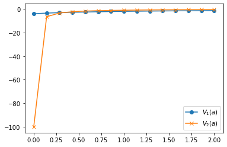

```python
## Funções Valor
plt.plot(a_grid, V1, "-o", label="$V_{1}(a)$")
plt.plot(a_grid, V2, "-x", label="$V_{2}(a)$")
plt.legend()
```

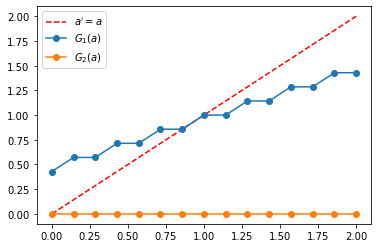

```python
## Funções Políticas
plt.plot(a_grid, a_grid, "--r", label="$a'=a$")  # Reta de 45 graus
plt.plot(a_grid, G1, "-o", label="$G_{1}(a)$")
plt.plot(a_grid, G2, "-o", label="$G_{2}(a)$")
plt.legend()
```

Note que não importa a riqueza do último período, não irá poupar nada ($a_3 = 0, \forall a$)

## Generalização do modelo

```python
T = 4
beta, delta = .98, 2
y_grid = np.array([1, 1, .01, .01])  # Dotações em cada t - aqui não está generalizado, precisa preencher com a mesma quantidade de T
a_max, n_a = 2, 15
A = 0  # A-barra (p/ restrição de crédito)
a_grid = np.linspace(A, a_max, n_a)


## Problema no período t
V = np.zeros((n_a, T+1))  # T+1 por último função valor igual a 0
iG = np.zeros((n_a, T), dtype = np.int32)  # dtype para ter apenas número inteiros (índices)

## Preencher e maximizar a função objetivo
for t in range(T, 0, -1):
    for i_a in range(n_a):
        F_OBJ = np.zeros((n_a, n_a))
        a = a_grid[i_a]

        for i_aa in range(n_a):
            aa = a_grid[i_aa]
            c = y_grid[t-1] + a - aa

            if c < 0.:
                F_OBJ[i_a, i_aa] = -np.inf
            else:
                F_OBJ[i_a, i_aa] = u(c) + beta * V[i_aa, t]  # descontando V2

            V[i_a, t-1] = np.max(F_OBJ[i_a,:])
            iG[i_a, t-1] = np.argmax(F_OBJ[i_a,:])


# Gerando valores da função valor a partir dos índices de iG2
G = a_grid[iG]
```

#### Gráficos

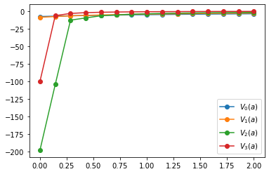

```python
## Funções Valor
for t in range(T):
    plt.plot(a_grid, V[:, t], "-o", label=f"$V_{t}(a)$")
plt.legend()
```

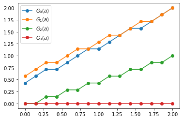

```python
## Funções Políticas
for t in range(T):
    plt.plot(a_grid, G[:, t], "-o", label=f"$G_{t}(a)$")
plt.legend()
```

## Estudando a evolução da riqueza de um indivíduo

```
<function matplotlib.pyplot.show(close=None, block=None)>
```

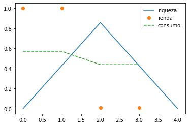

```python
ia_t = np.zeros(T+1, dtype=np.int32)
a_t = np.zeros(T+1)

ia_t[0] = 0  # Riqueza inicial
a_t[0] = a_grid[ia_t[0]]

for t in range(1, T+1):
    ia_t[t] = iG[ia_t[t-1], t-1]
    a_t[t] = a_grid[ia_t[t]]


# calculando consumo para inserir no gráfico
c_t = np.zeros(T)
for i in range(T):
    c_t[i] = y_grid[i] + a_t[i] - a_t[i+1]


## Gráficos
figure, ax = plt.subplots()
plt.plot(range(T+1), a_t, label="riqueza")
plt.plot(range(T), y_grid, "o", label="renda")
plt.plot(range(T), c_t, "--", label="consumo")
plt.legend(loc="best")
plt.show
```

Formalmente, no caso geral, o problema de maximização (sequencial), dados $(a_1, \{y_t\}^T_{t=1})$, é: $$ W(a_1, \{y_t\}^T_{t=1}) \equiv \max_{-\bar{A}\ \le\ a_{t+1}\ \le\ y_t + a_t}\left\{ \sum^T_{t=1}{\beta^{t-1} u(y_t + a_t + a_{t+1})} \right\} $$ em que $u(c) = \frac{c^{1-\delta}}{1-\delta}$

**Definição 3 (Problema período de vida $t \in \{1, 2, ..., T\}$)** $$ V_t(a_t) \equiv \max_{-\bar{A}\ \le\ a_{t+1}\ \le\ y_t + a_t}\left\{ u(y_t + a_t + a_{t+1}) + \beta V_{t+1}(a_{t+1}) \right\} $$ em que $V_{T+1}(a_{T+1}) = 0$ para cada $a_{T+1}$.

**Observação 4.** Note que $$ W(a_1, \{y_t\}^T_{t=1}) = V_1(a_1) $$

## Estrutura OLG (Gerações Sobrepostas)

### Avançando um período

```python
# Distribuição de pessoas nos estados
# $\phi(a, t)$: massa de pessoas com riqueza $a$ na idade $t$

phi = np.zeros((n_a, T))
print(phi)
```

```
[[0. 0. 0. 0.]
 [0. 0. 0. 0.]
 [0. 0. 0. 0.]
 [0. 0. 0. 0.]
 [0. 0. 0. 0.]
 [0. 0. 0. 0.]
 [0. 0. 0. 0.]
 [0. 0. 0. 0.]
 [0. 0. 0. 0.]
 [0. 0. 0. 0.]
 [0. 0. 0. 0.]
 [0. 0. 0. 0.]
 [0. 0. 0. 0.]
 [0. 0. 0. 0.]
 [0. 0. 0. 0.]]
```

```python
# Preenchendo phi | Valor inicial é arbitrário e positivo (vai normalizar depois)
for t in range(T):
    phi[0, t] = 1

    for i in range(1, n_a):
        phi[i, t] = phi[i-1, t] / (t+4)  # arbitrário

    phi[:, t] = phi[:, t] / sum(phi[:, t])  # normalizando coluna t

phi = phi / sum(sum(phi))  #  Normalizando a matriz inteira
    # sum(phi) soma todas as colunas, que são iguais a 1, dado que foi normalizada
    # cada elemento é dividido pela quantidade de colunas T, dado que sum(sum(phi)) = T

print("A distribuição inicial $\\phi(a, t)$ é:\n", np.round(phi, 3),"\n")
print("A massa de pessoas com idade = 0 é", sum(phi[:, 0])*100, "%")
print("A massa de pessoas com idade = 2 é", sum(phi[:, 2])*100, "%\n")
print(f"A massa de pessoas com riqueza = {a_grid[0] :.2f} é {sum(phi[0,:])*100 :.1f}%")
print(f"A massa de pessoas com riqueza = {a_grid[3] :.2f} é {sum(phi[3,:])*100 :.1f}%")
```

```
A distribuição inicial $\phi(a, t)$ é:
 [[0.188 0.2   0.208 0.214]
 [0.047 0.04  0.035 0.031]
 [0.012 0.008 0.006 0.004]
 [0.003 0.002 0.001 0.001]
 [0.001 0.    0.    0.   ]
 [0.    0.    0.    0.   ]
 [0.    0.    0.    0.   ]
 [0.    0.    0.    0.   ]
 [0.    0.    0.    0.   ]
 [0.    0.    0.    0.   ]
 [0.    0.    0.    0.   ]
 [0.    0.    0.    0.   ]
 [0.    0.    0.    0.   ]
 [0.    0.    0.    0.   ]
 [0.    0.    0.    0.   ]]

A massa de pessoas com idade = 0 é 25.0 %
A massa de pessoas com idade = 2 é 25.0 %

A massa de pessoas com riqueza = 0.00 é 81.0%
A massa de pessoas com riqueza = 0.43 é 0.6%
```

```python
# Próximo período
new_phi = np.zeros((n_a, T))

for t in range(T):
    for i_a in range(n_a):
        medida = phi[i_a, t]  # Proporção de pessoas com riqueza i_a e idade t no período atual
        i_aa = iG[i_a, t]  # Índice de a', escolhido pelas pessoas com (i_aa, t)

        # Preenchendo new_phi para par (a', t+1) com proporção de pessoas de hoje
        if t < T-1:
            # Se não estivermos no último período de vida
            new_phi[i_aa, t+1] += medida  # está somando ao new_phi[i_aa, t] anterior, pois mais de um "a" pode ir a um "a'"
        else:
            # Se estivermos no último período de vida, deixa para seu herdeiro
            new_phi[i_aa, 0] += medida

print("A nova distribuição $\\phi'(a, t)$ é:\n", np.round(new_phi, 3))
```

```
A nova distribuição $\phi'(a, t)$ é:
 [[0.25  0.    0.    0.243]
 [0.    0.    0.    0.007]
 [0.    0.    0.    0.   ]
 [0.    0.188 0.    0.   ]
 [0.    0.047 0.2   0.   ]
 [0.    0.015 0.04  0.   ]
 [0.    0.001 0.01  0.   ]
 [0.    0.    0.    0.   ]
 [0.    0.    0.    0.   ]
 [0.    0.    0.    0.   ]
 [0.    0.    0.    0.   ]
 [0.    0.    0.    0.   ]
 [0.    0.    0.    0.   ]
 [0.    0.    0.    0.   ]
 [0.    0.    0.    0.   ]]
```

### Iterando até convergência da distribuição

```python
# Distribuição Inicial
phi = np.zeros((n_a, T))

# Preenchendo phi | Valor inicial é arbitrário e positivo (vai normalizar depois)
for t in range(T):
    phi[0, t] = 1

    for i in range(1, n_a):
        phi[i, t] = phi[i-1, t] / (t+4)  # arbitrário

    phi[:, t] = phi[:, t] / sum(phi[:, t])  # normalizando coluna t

phi = phi / sum(sum(phi))  #  Normalizando a matriz inteira
    # sum(phi) soma todas as colunas, que são iguais a 1, dado que foi normalizada
    # cada elemento é dividido pela quantidade de colunas T, dado que sum(sum(phi)) = T

print("A distribuição inicial $\\phi(a, t)$ é:\n", np.round(phi, 3),"\n")
```

```
A distribuição inicial $\phi(a, t)$ é:
 [[0.188 0.2   0.208 0.214]
 [0.047 0.04  0.035 0.031]
 [0.012 0.008 0.006 0.004]
 [0.003 0.002 0.001 0.001]
 [0.001 0.    0.    0.   ]
 [0.    0.    0.    0.   ]
 [0.    0.    0.    0.   ]
 [0.    0.    0.    0.   ]
 [0.    0.    0.    0.   ]
 [0.    0.    0.    0.   ]
 [0.    0.    0.    0.   ]
 [0.    0.    0.    0.   ]
 [0.    0.    0.    0.   ]
 [0.    0.    0.    0.   ]
 [0.    0.    0.    0.   ]]
```

```python
# Realizando iterações até a convergência
phi_path = [phi[:]]  # Usando dois pontos para efetuar cópia de matriz (não correr risco de vincular ao mesmo lugar)
norm_distr = np.inf  # Norma apenas para entrar no loop
tol_distr = 1e-5  # tolerância para convergência

i = 0  # contador de períodos
while norm_distr > tol_distr:
    new_phi = np.zeros((n_a, T))
    i += 1

    for t in range(T):
        for i_a in range(n_a):
            medida = phi[i_a, t]  # Proporção de pessoas com riqueza i_a e idade t no período atual
            i_aa = iG[i_a, t]  # Índice de a', escolhido pelas pessoas com (i_aa, t)

            # Preenchendo new_phi para par (a', t+1) com proporção de pessoas de hoje
            if t < T-1:
                # Se não estivermos no último período de vida
                new_phi[i_aa, t+1] += medida  # está somando ao new_phi[i_aa, t] anterior, pois mais de um "a" pode ir a um "a'"
            else:
                # Se estivermos no último período de vida, deixa para seu herdeiro
                new_phi[i_aa, 0] += medida
    print(f"A distribuição $\\phi(a, t)$ após {i} período(s) é:\n", np.round(new_phi, 3))

    norm_distr = np.max(abs(new_phi - phi))  # Atualizando o valor da norma
    print("A norma é igual a", round(norm_distr, 6), "\n")

    phi_path.append(new_phi[:])
    phi = new_phi[:]
```

```
A distribuição $\phi(a, t)$ após 1 período(s) é:
 [[0.25  0.    0.    0.243]
 [0.    0.    0.    0.007]
 [0.    0.    0.    0.   ]
 [0.    0.188 0.    0.   ]
 [0.    0.047 0.2   0.   ]
 [0.    0.015 0.04  0.   ]
 [0.    0.001 0.01  0.   ]
 [0.    0.    0.    0.   ]
 [0.    0.    0.    0.   ]
 [0.    0.    0.    0.   ]
 [0.    0.    0.    0.   ]
 [0.    0.    0.    0.   ]
 [0.    0.    0.    0.   ]
 [0.    0.    0.    0.   ]
 [0.    0.    0.    0.   ]]
A norma é igual a 0.208333

A distribuição $\phi(a, t)$ após 2 período(s) é:
 [[0.25  0.    0.    0.   ]
 [0.    0.    0.    0.   ]
 [0.    0.    0.    0.24 ]
 [0.    0.25  0.    0.01 ]
 [0.    0.    0.    0.   ]
 [0.    0.    0.    0.   ]
 [0.    0.    0.188 0.   ]
 [0.    0.    0.047 0.   ]
 [0.    0.    0.015 0.   ]
 [0.    0.    0.    0.   ]
 [0.    0.    0.    0.   ]
 [0.    0.    0.    0.   ]
 [0.    0.    0.    0.   ]
 [0.    0.    0.    0.   ]
 [0.    0.    0.    0.   ]]
A norma é igual a 0.243056

A distribuição $\phi(a, t)$ após 3 período(s) é:
 [[0.25  0.    0.    0.   ]
 [0.    0.    0.    0.   ]
 [0.    0.    0.    0.   ]
```

[output cut: 34 more lines]

```
 [0.   0.   0.   0.  ]
 [0.   0.   0.   0.  ]
 [0.   0.25 0.   0.25]
 [0.   0.   0.   0.  ]
 [0.   0.   0.   0.  ]
 [0.   0.   0.25 0.  ]
 [0.   0.   0.   0.  ]
 [0.   0.   0.   0.  ]
 [0.   0.   0.   0.  ]
 [0.   0.   0.   0.  ]
 [0.   0.   0.   0.  ]
 [0.   0.   0.   0.  ]
 [0.   0.   0.   0.  ]
 [0.   0.   0.   0.  ]]
A norma é igual a 0.0
```

## Agregados Macroeconômicos

```python
C_agreg = 0
Y_agreg = 0
S_agreg = 0

for t in range(T):
    for i_a in range(n_a):
        a = a_grid[i_a]  # Pegando o valor de a com índice i_a
        i_aa = iG[i_a, t]  # Pegando o índice de a', dado a
        y = y_grid[t]  # Pegando dotação, dada idade t

        c = y + a - aa
        medida = phi[i_a, t]  # Proporção de pessoas com riqueza a e idade t

        C_agreg += c * medida
        Y_agreg += y * medida
        S_agreg += (y-c) * medida
#         S_agreg += (aa-a) * medida

print("Consumo agregado =", np.round(C_agreg, 3))
print("Dotação agregada =", np.round(Y_agreg, 3))
print("Riqueza agregada =", np.round(S_agreg, 3))
```

```
Consumo agregado = -1.066
Dotação agregada = 0.505
Riqueza agregada = 1.571
```

Conferir se a poupança (riqueza) agregada é igual a zero. Se não for, precisa ajustar taxa de juros $r$ (omitido nesta resolução) tal que a riqueza seja igual a zero. O guess $r$ nas iterações talvez seja por meio do método de penalidade.